# Chakrayuddh_Kimsovanna_Food_Hub_Assignment_Full_Code (1)

## **Project 1: Food Hub Data Analysis Assignment**

### **Setting Up**

```python
import numpy as np
import pandas as pd

import matplotlib.pyplot as plt
import seaborn as sns
```

```python
from google.colab import drive
drive.mount('/content/drive')
```

```python
data = pd.read_csv('/content/drive/MyDrive/Data Science & Business Analytics Program/Python Foundations/Project/foodhub_order.csv')
```

### **Question 1**

```python
data.shape
```

```
(1898, 9)
```

```python
print("\033[1mObservation:\033[0m There are", data.shape[0], 'rows and', data.shape[1], "columns present in this dataset.")
```

```
Observation: There are 1898 rows and 9 columns present in this dataset.
```

### **Question 2**

```python
data.info()
```

```
<class 'pandas.core.frame.DataFrame'>
RangeIndex: 1898 entries, 0 to 1897
Data columns (total 9 columns):
 #   Column                 Non-Null Count  Dtype
---  ------                 --------------  -----
 0   order_id               1898 non-null   int64
 1   customer_id            1898 non-null   int64
 2   restaurant_name        1898 non-null   object
 3   cuisine_type           1898 non-null   object
 4   cost_of_the_order      1898 non-null   float64
 5   day_of_the_week        1898 non-null   object
 6   rating                 1898 non-null   object
 7   food_preparation_time  1898 non-null   int64
 8   delivery_time          1898 non-null   int64
dtypes: float64(1), int64(4), object(4)
memory usage: 133.6+ KB
```

**Observation:** The datatypes of the different columns in the dataset include *int*, *float*, and *object*.

### **Question 3**

```python
data['order_id'].unique()
```

```
array([1477147, 1477685, 1477070, ..., 1477819, 1477513, 1478056])
```

```python
data['customer_id'].unique()
```

```
array([337525, 358141,  66393, ...,  97838, 292602, 397537])
```

```python
data['restaurant_name'].unique()
```

```
array(['Hangawi', 'Blue Ribbon Sushi Izakaya', 'Cafe Habana',
       'Blue Ribbon Fried Chicken', 'Dirty Bird to Go',
       'Tamarind TriBeCa', 'The Meatball Shop', 'Barbounia',
       'Anjappar Chettinad', 'Bukhara Grill',
       'Big Wong Restaurant \x8c_¤¾Ñ¼', 'Empanada Mama (closed)', 'Pylos',
       "Lucky's Famous Burgers", 'Shake Shack', 'Sushi of Gari',
       'RedFarm Hudson', 'Blue Ribbon Sushi',
       'Five Guys Burgers and Fries', 'Tortaria', 'Cafe Mogador',
       'Otto Enoteca Pizzeria', 'Vezzo Thin Crust Pizza',
       'Sushi of Gari 46', 'The Kati Roll Company', 'Klong',
       '5 Napkin Burger', 'TAO', 'Parm', 'Sushi Samba',
       'Haru Gramercy Park', 'Chipotle Mexican Grill $1.99 Delivery',
       'RedFarm Broadway', 'Cafeteria', 'DuMont Burger',
       "Sarabeth's East", 'Hill Country Fried Chicken', 'Bistango',
       "Jack's Wife Freda", "Mamoun's Falafel", 'Prosperity Dumpling',
       'Blue Ribbon Sushi Bar & Grill', 'Westville Hudson',
       'Blue Ribbon Brooklyn', 'Nobu Next Door', 'Osteria Morini',
       'Haandi', 'Benihana', 'Han Dynasty', 'Chote Nawab',
       'Mission Cantina', "Xi'an Famous Foods", 'Rubirosa',
       "Joe's Shanghai \x8e_À\x8eü£¾÷´", 'Bareburger', 'The Odeon',
       'Pongsri Thai', 'Yama Japanese Restaurant', 'Momoya',
       'Balthazar Boulangerie', 'CafÌ© China', 'Boqueria',
       'Song Thai Restaurant & Bar', 'Five Leaves',
       'Pinto Nouveau Thai Bistro', "Amy Ruth's", 'Pepe Giallo',
       'indikitch', 'Yama 49', 'Piccolo Angolo', 'Pepe Rosso To Go',
       "L'Express", 'Amma', 'Delicatessen', "S'MAC",
       "Vanessa's Dumplings", 'Bhatti Indian Grill', 'Taro Sushi',
       'Donburi-ya', 'Hatsuhana', 'Samurai Mama', 'Waverly Diner',
       'Tarallucci e Vino Restaurant', "P.J. Clarke's",
       'Lantern Thai Kitchen', 'ilili Restaurant', 'The Smile',
       "Vanessa's Dumpling House", "Bubby's ", 'Woorijip',
       'Dirty Bird To Go (archived)', 'Haveli Indian Restaurant',
       'Dos Caminos', 'da Umberto', 'Sushi of Gari Tribeca',
       'Burger Joint', 'Room Service', "Sarabeth's Restaurant",
       'Xe May Sandwich Shop', 'Hibino', 'Mira Sushi', 'Melt Shop',
       'J. G. Melon', 'Hummus Place', 'Saravanaa Bhavan',
       'Friend of a Farmer', 'The Loop', 'Balade', 'Posto',
       'Terakawa Ramen', 'Kambi Ramen House', 'Wo Hop Restaurant',
       'Spice Thai', "Dickson's Farmstand Meats",
       'UVA Wine Bar & Restaurant', 'Serafina Fabulous Pizza',
       'Gaia Italian Cafe', 'Chola Eclectic Indian Cuisine',
       'Hot Kitchen', 'Junoon', 'Ravagh Persian Grill', 'Rohm Thai',
       'Dig Inn Seasonal Market', 'Olea', 'Cho Dang Gol',
       'El Parador Cafe', 'Socarrat Paella Bar',
       "Don's Bogam BBQ & Wine Bar", 'Alidoro', "Tony's Di Napoli",
       'Cipriani Le Specialita', 'Sushi Choshi', 'Kanoyama', 'V-Nam Cafe',
       'Zero Otto Nove', 'Dos Caminos Soho', 'Go! Go! Curry!',
       'La Follia', 'Izakaya Ten', '12 Chairs', 'Philippe Chow',
       'The MasalaWala', 'brgr', "Carmine's", 'Asuka Sushi', 'Aurora',
       "Sarabeth's", 'Crema Restaurante', "Big Daddy's",
       'Moonstruck on Second', 'Cafe de La Esquina', 'Olive Garden',
       '67 Burger', 'Tres Carnes', "Schnipper's Quality Kitchen",
       'Nha Trang One', 'Market Table', 'Galli Restaurant',
       'Hampton Chutney Co.', 'Byblos Restaurant',
       'Grand Sichuan International', 'Le Grainne Cafe', 'Il Bambino',
       'Kori Restaurant and Bar', 'DespaÌ±a', 'Lamarca Pasta',
       'Lucky Strike', "Paul & Jimmy's", 'Hunan Manor', "Coppola's East",
       'Emporio', 'Wa Jeal', 'Le Zie 2000 Trattoria', 'Rye House',
       "Hiroko's Place", 'Frank Restaurant', "Sarabeth's West",
       "'wichcraft"], dtype=object)
```

```python
data['cuisine_type'].unique()
```

```
array(['Korean', 'Japanese', 'Mexican', 'American', 'Indian', 'Italian',
       'Mediterranean', 'Chinese', 'Middle Eastern', 'Thai', 'Southern',
       'French', 'Spanish', 'Vietnamese'], dtype=object)
```

```python
data['cost_of_the_order'].unique()
```

```
array([30.75, 12.08, 12.23, 29.2 , 11.59, 25.22,  6.07,  5.97, 16.44,
        7.18,  5.92,  8.1 , 24.3 , 11.3 , 12.13, 16.2 , 16.98, 33.03,
       14.12, 24.2 , 15.91, 29.1 ,  8.92, 15.86, 21.88, 14.02,  9.17,
       12.18, 31.33, 29.05,  8.39,  9.12, 15.47, 16.01, 29.83, 19.89,
       19.35, 33.22, 24.25, 22.75,  6.74, 13.78, 16.93, 29.39, 20.23,
       14.6 ,  6.79, 31.38,  8.34, 12.46, 14.55, 32.93,  8.  , 13.05,
        5.67, 29.29, 16.15, 13.34,  9.75,  6.69,  4.75, 12.56, 21.2 ,
       19.31, 16.3 , 25.27, 14.79,  5.72,  9.22, 16.39, 17.03, 21.83,
       31.29, 11.83, 22.26, 20.47, 15.81, 22.36,  8.68, 12.9 , 29.15,
        7.86, 16.1 , 12.95, 11.69, 12.32, 14.99, 10.38,  9.65,  5.77,
        9.56, 29.34, 11.16, 14.07, 22.8 , 15.23, 16.49,  8.83, 16.25,
       16.83, 10.24, 19.4 , 13.97, 13.  ,  8.49, 20.18, 19.59, 16.11,
       12.27, 13.39,  9.02, 15.33, 31.43, 29.35, 15.28,  9.6 ,  8.88,
       15.96,  8.05,  8.54,  7.23, 19.69,  9.27,  8.97, 11.64, 13.15,
        9.41,  9.07, 14.46,  6.7 , 19.45, 12.22, 29.25, 16.05, 17.08,
       32.98, 13.73, 14.31, 14.7 , 15.52,  6.11, 21.93, 15.76,  9.46,
       12.61, 22.85, 16.06, 21.39,  8.25, 14.94, 14.26, 21.34, 14.16,
        5.68, 15.57, 14.45,  8.15,  8.78,  8.59, 15.62,  5.87,  6.01,
        9.85,  6.84,  5.82,  7.96,  9.7 ,  4.85,  6.06, 12.66,  6.02,
        7.08, 12.37, 14.84, 22.31, 13.1 , 14.75, 24.35, 25.17,  9.26,
        9.55, 13.92,  4.66, 13.87,  7.61, 15.72,  8.35, 14.21, 14.65,
        4.71,  8.63, 13.68, 11.93, 35.41,  6.64, 10.72,  8.73, 16.78,
        5.58, 13.63, 29.54, 29.49, 15.04, 18.24,  4.47,  8.98, 15.71,
        8.93,  9.51,  9.61,  7.38, 13.19, 10.82,  6.26,  8.2 ,  7.33,
       12.71,  5.63, 17.07,  5.48, 22.12, 15.77,  6.45, 11.79, 11.98,
       20.32, 28.57, 22.07, 21.29, 14.41, 29.88,  4.8 , 10.14,  8.44,
       16.54,  7.71, 29.78, 31.86, 19.98, 12.42, 12.52, 15.38,  8.3 ,
       13.24,  8.01, 29.68,  9.32, 12.51,  5.34,  6.4 , 19.3 , 17.85,
       16.88, 13.77,  5.73, 11.84, 15.67, 13.58, 33.18,  6.55, 20.52,
       28.62, 15.18, 29.3 , 12.81, 29.44, 11.11, 14.5 , 22.02, 11.88,
       33.32, 18.43, 12.47, 20.13, 20.57, 15.09, 19.74, 18.04, 31.67,
        5.05,  7.03, 14.8 , 12.17,  7.28, 15.13,  7.81, 16.74,  9.31,
       21.25, 31.87, 19.02, 34.19,  5.53, 22.46, 29.73, 10.43, 19.5 ,
        4.9 , 15.37,  7.67,  7.91, 13.53, 33.37, 19.6 , 13.48, 20.71,
       20.61,  7.66, 10.86,  7.95, 20.86, 29.59])
```

```python
data['day_of_the_week'].unique()
```

```
array(['Weekend', 'Weekday'], dtype=object)
```

```python
data['rating'].unique()
```

```
array(['Not given', '5', '3', '4'], dtype=object)
```

```python
data['food_preparation_time'].unique()
```

```
array([25, 23, 20, 28, 33, 21, 29, 34, 24, 30, 35, 32, 31, 27, 22, 26])
```

```python
data['delivery_time'].unique()
```

```
array([20, 23, 28, 15, 24, 21, 30, 26, 22, 17, 25, 16, 29, 27, 18, 31, 32,
       19, 33])
```

```python
data[data['rating']=='Not given'].shape[0]
```

```
736
```

**Observation:** There is not any missing value in the data, as shown from the data summaries above. Additionally, the table given by the command 'data.info()' shows that every single column does not have any missing value as the number of non-null is 1898, which is exactly the number of rows there are in the dataset. However, one variable, 'rating', has 736 counts of 'not given' although this does not necessarily qualify as missing values.

### **Question 4**

```python
data['food_preparation_time'].describe()
```

```
count    1898.000000
mean       27.371970
std         4.632481
min        20.000000
25%        23.000000
50%        27.000000
75%        31.000000
max        35.000000
Name: food_preparation_time, dtype: float64
```

**Observation:** In terms of food preparation time once an order is placed, the minimum time is 20 minutes; the average time is around 27.37 minutes; and the maximum time is 35 minutes.

### **Question 5**

```python
data[data['rating']=='Not given'].shape[0]
```

```
736
```

```python
data[data['rating']=='Not given'].value_counts
```

```
<bound method DataFrame.value_counts of       order_id  customer_id             restaurant_name cuisine_type  \
0      1477147       337525                     Hangawi       Korean
1      1477685       358141   Blue Ribbon Sushi Izakaya     Japanese
6      1477894       157711           The Meatball Shop      Italian
10     1477895       143926  Big Wong Restaurant _¤¾Ñ¼      Chinese
14     1478198        62667      Lucky's Famous Burgers     American
...        ...          ...                         ...          ...
1887   1476873       237616                 Shake Shack     American
1891   1476981       138586                 Shake Shack     American
1892   1477473        97838                 Han Dynasty      Chinese
1895   1477819        35309           Blue Ribbon Sushi     Japanese
1897   1478056       120353           Blue Ribbon Sushi     Japanese

      cost_of_the_order day_of_the_week     rating  food_preparation_time  \
0                 30.75         Weekend  Not given                     25
```

[output cut: 25 more lines]

**Observation:** Based on the statistics above, there are 736 out of the total 1898 orders that are not rated.

### **Question 6**

#### **Statistics on Order ID**

```python
data['order_id'].nunique()
```

```
1898
```

**Observation:** There are a total of 1898 unique order IDs.

#### **Statistics on Customer ID**

```python
data['customer_id'].nunique()
```

```
1200
```

**Observation:** There are 1200 unique customer IDs, meaning that there are occurrences of different orders being made by the same customer.

#### **Statistics on Restaurant Name**

```python
data['restaurant_name'].nunique()
```

```
178
```

```python
pd.set_option("display.max_rows", None)
data['restaurant_name'].value_counts()
```

```
Shake Shack                              219
The Meatball Shop                        132
Blue Ribbon Sushi                        119
Blue Ribbon Fried Chicken                 96
Parm                                      68
RedFarm Broadway                          59
RedFarm Hudson                            55
TAO                                       49
Han Dynasty                               46
Blue Ribbon Sushi Bar & Grill             44
Nobu Next Door                            42
Rubirosa                                  37
Sushi of Gari 46                          37
Momoya                                    30
Five Guys Burgers and Fries               29
Blue Ribbon Sushi Izakaya                 29
Bareburger                                27
Tamarind TriBeCa                          27
Jack's Wife Freda                         25
Sushi of Gari Tribeca                     24
Chipotle Mexican Grill $1.99 Delivery     23
The Smile                                 18
ilili Restaurant                          18
Cafe Mogador                              18
Yama Japanese Restaurant                  18
The Kati Roll Company                     16
Sushi of Gari                             16
Cafe Habana                               16
P.J. Clarke's                             15
J. G. Melon                               15
Westville Hudson                          15
Osteria Morini                            14
Hill Country Fried Chicken                14
Empanada Mama (closed)                    13
Vanessa's Dumplings                       13
Burger Joint                              12
S'MAC                                     12
Otto Enoteca Pizzeria                     12
Melt Shop                                 11
Sushi Samba                               11
```

[output cut: 124 more lines]

```
Wo Hop Restaurant                          1
Spice Thai                                 1
Gaia Italian Cafe                          1
Chola Eclectic Indian Cuisine              1
Rohm Thai                                  1
Dig Inn Seasonal Market                    1
Socarrat Paella Bar                        1
Alidoro                                    1
Cipriani Le Specialita                     1
Sushi Choshi                               1
Dos Caminos Soho                           1
La Follia                                  1
Philippe Chow                              1
'wichcraft                                 1
Name: restaurant_name, dtype: int64
```

#### **Statistics on Cuisine Type**

```python
data['cuisine_type'].nunique()
```

```
14
```

```python
pd.set_option("display.max_rows", None)
data['cuisine_type'].value_counts()
```

```
American          584
Japanese          470
Italian           298
Chinese           215
Mexican            77
Indian             73
Middle Eastern     49
Mediterranean      46
Thai               19
French             18
Southern           17
Korean             13
Spanish            12
Vietnamese          7
Name: cuisine_type, dtype: int64
```

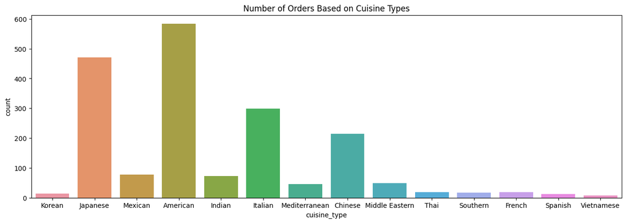

```python
plt.figure(figsize=(16,5))
plt.title("Number of Orders Based on Cuisine Types")
sns.countplot(data,x='cuisine_type')
plt.show;
```

**Observation:** There are 14 different types of cuisines listed in the dataset. Most of which are American, followed by Japanese, Italian and Chinese, with 584, 470, 298 and 215 orders respectively. The least popular cuisine type is Vietnamese with only 7 orders.

#### **Statistics on Cost of the Order**

```python
data['cost_of_the_order'].describe()
```

```
count    1898.000000
mean       16.498851
std         7.483812
min         4.470000
25%        12.080000
50%        14.140000
75%        22.297500
max        35.410000
Name: cost_of_the_order, dtype: float64
```

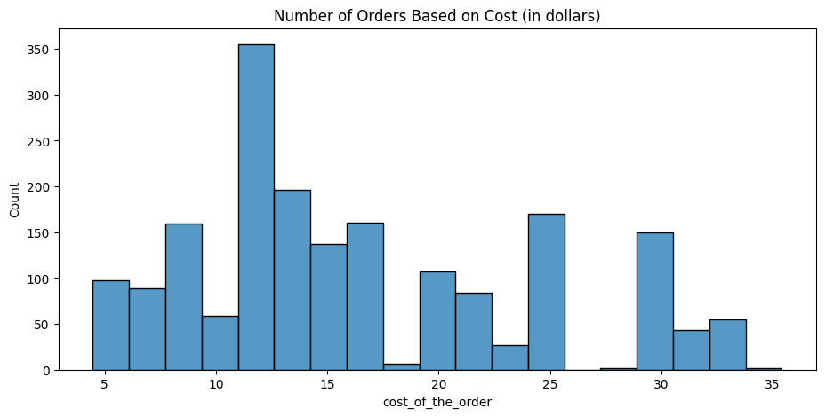

```python
plt.figure(figsize=(11,5))
plt.title("Number of Orders Based on Cost (in dollars)")
sns.histplot(data,x='cost_of_the_order')
plt.show;
```

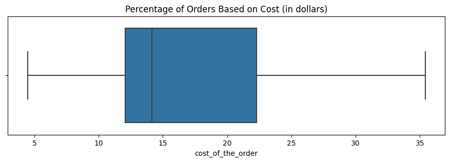

```python
plt.figure(figsize=(11,3))
plt.title("Percentage of Orders Based on Cost (in dollars)")
sns.boxplot(data,x='cost_of_the_order')
plt.show;
```

**Observation:** Based on the statistics and graphs above, one can see that the average cost is around 16.50 dollars; the lowest cost is 4.47 dollars and the highest cost is 35.41 dollars. The median cost is 14.14 dollars. Additionally, 25% of orders (1st quartile) have the cost of 12.08 dollars or less and 75% of orders (3rd quartile) have the cost of around 22.30 dollars or less.

#### **Statistics on Day of the Week**

```python
data['day_of_the_week'].nunique()
```

```
2
```

```python
data['day_of_the_week'].value_counts()
```

```
Weekend    1351
Weekday     547
Name: day_of_the_week, dtype: int64
```

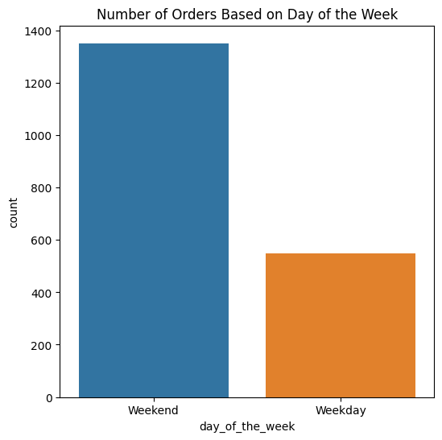

```python
plt.figure(figsize=(6,6))
plt.title("Number of Orders Based on Day of the Week")
sns.countplot(data,x='day_of_the_week')
plt.show;
```

**Observation:** The dataset only has weekends and weekdays, rather than the individual days themselves. There are 1351 orders on the weekend, whereas there are only 547 orders on the weekdays. This shows that despite the weekends having only two days, most people would rather order food, while on the weekdays, it can be assumed that people tend to cook food for themselves.

#### **Statistics on Rating**

```python
data['rating'].unique()
```

```
array(['Not given', '5', '3', '4'], dtype=object)
```

```python
data['rating'].nunique()
```

```
4
```

```python
pd.set_option("display.max_rows", None)
data['rating'].value_counts()
```

```
Not given    736
5            588
4            386
3            188
Name: rating, dtype: int64
```

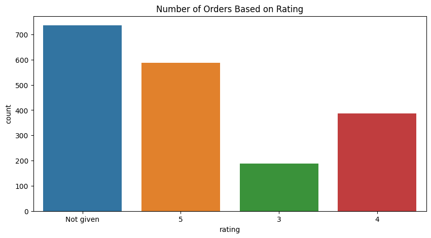

```python
plt.figure(figsize=(10,5))
plt.title("Number of Orders Based on Rating")
sns.countplot(data,x='rating')
plt.show;
```

**Observation:** In terms of rating, there are only 4 different types: 'not given', '5', '4' and '3'; there is no '2' or '1'. The rating that has the most orders is 'not given', with 736 orders, while the rating with the least amount of orders is '3', with only 188 orders.

#### **Statistics on Food Preparation Time**

```python
data['food_preparation_time'].describe()
```

```
count    1898.000000
mean       27.371970
std         4.632481
min        20.000000
25%        23.000000
50%        27.000000
75%        31.000000
max        35.000000
Name: food_preparation_time, dtype: float64
```

```python
pd.set_option("display.max_rows", None)
data['food_preparation_time'].value_counts()
```

```
21    135
23    123
27    123
22    123
28    121
24    121
20    119
30    119
33    118
35    117
31    116
26    115
25    113
34    113
32    113
29    109
Name: food_preparation_time, dtype: int64
```

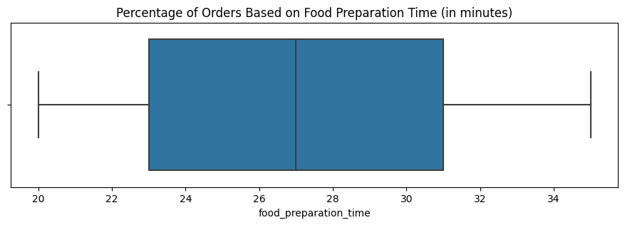

```python
plt.figure(figsize=(11,3))
plt.title("Percentage of Orders Based on Food Preparation Time (in minutes)")
sns.boxplot(data,x='food_preparation_time')
plt.show;
```

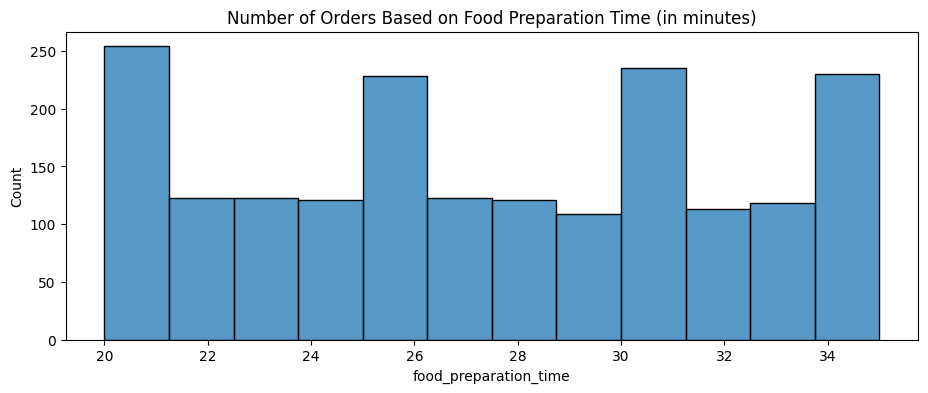

```python
plt.figure(figsize=(11,4))
plt.title("Number of Orders Based on Food Preparation Time (in minutes)")
sns.histplot(data,x='food_preparation_time')
plt.show;
```

**Observation:** As mentioned earlier, the mean food preparation time is 27.37 minutes, while the minimum and maximum are 20 and 35 minutes respectively. Most of the orders are done within 21 minutes with 135 orders, and the food preparation time with the least amount of orders is 29 minutes with 109 orders. About 25% of all food orders are prepared within 23 minutes and 75% of orders are prepared within 31 minutes.

#### **Statistics on Delivery Time**

```python
data['delivery_time'].describe()
```

```
count    1898.000000
mean       24.161749
std         4.972637
min        15.000000
25%        20.000000
50%        25.000000
75%        28.000000
max        33.000000
Name: delivery_time, dtype: float64
```

```python
pd.set_option("display.max_rows", None)
data['delivery_time'].value_counts()
```

```
24    162
28    148
29    148
26    141
27    138
30    133
25    120
19     90
16     90
20     88
15     87
22     85
18     83
21     81
17     78
23     77
32     59
33     49
31     41
Name: delivery_time, dtype: int64
```

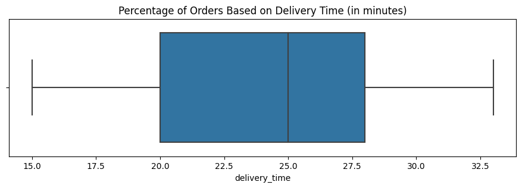

```python
plt.figure(figsize=(11,3))
plt.title("Percentage of Orders Based on Delivery Time (in minutes)")
sns.boxplot(data,x='delivery_time')
plt.show;
```

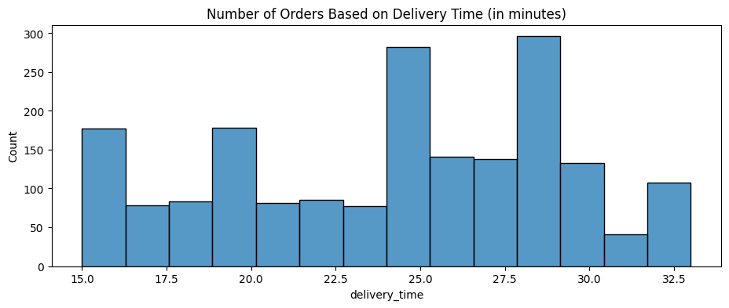

```python
plt.figure(figsize=(11,4))
plt.title("Number of Orders Based on Delivery Time (in minutes)")
sns.histplot(data,x='delivery_time')
plt.show;
```

### **Question 7**

```python
data['restaurant_name'].value_counts().nlargest(n=5)
```

```
Shake Shack                  219
The Meatball Shop            132
Blue Ribbon Sushi            119
Blue Ribbon Fried Chicken     96
Parm                          68
Name: restaurant_name, dtype: int64
```

**Observation:** The top 5 restaurants with the most number of orders received (from most to least) are Shake Shack, The Meatball Shop, Blue Ribbon Sushi, Blue Ribbon Fried Chicken and Parm.

### **Question 8**

```python
data_weekend_cuisine = data[data['day_of_the_week']=='Weekend']
data_weekend_cuisine['cuisine_type'].value_counts().nlargest(n=1)
```

```
American    415
Name: cuisine_type, dtype: int64
```

**Observation:** On the weekends, the most popular cuisine is American with 415 of the total 1898 orders.

### **Question 9**

```python
data[data['cost_of_the_order']>20].shape[0]
```

```
555
```

```python
(data[data['cost_of_the_order']>20].shape[0])/(data.shape[0])*100
```

```
29.24130663856691
```

```python
data_percent_20_dollars = data[data['cost_of_the_order']>20].shape[0]/(data.shape[0])*100

data_percent_20_dollars_rounded = str(round(data_percent_20_dollars, 2))
```

```python
print("\033[1mObservation:\033[0m There are ", data[data['cost_of_the_order']>20].shape[0], " orders that cost more than 20 dollars, which is approximately ", data_percent_20_dollars_rounded, "% of the total orders.", sep='')
```

```
Observation: There are 555 orders that cost more than 20 dollars, which is approximately 29.24% of the total orders.
```

### **Question 10**

```python
data_deliv_mean = data['delivery_time'].mean()
```

```python
data_deliv_mean_rounded = str(round(data_deliv_mean, 2))
```

```python
print("\033[1mObservation:\033[0m The mean order delivery time is", data_deliv_mean_rounded, "minutes.")
```

```
Observation: The mean order delivery time is 24.16 minutes.
```

### **Question 11**

```python
data['customer_id'].value_counts().nlargest(n=3)
```

```
52832    13
47440    10
83287     9
Name: customer_id, dtype: int64
```

**Observation:** The top 3 most frequent customers that can benefit from the 20% discount have the following IDs: '52832', '47440' and '83287'.

### **Question 12**

#### **Relationship Between Cuisine Type & Other Variables**

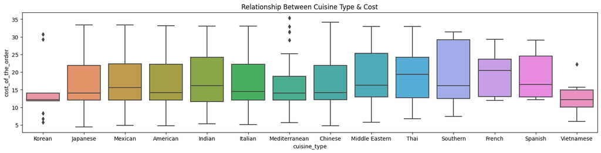

```python
plt.figure(figsize=(19,4))
plt.title("Relationship Between Cuisine Type & Cost")
sns.boxplot(data, x='cuisine_type', y='cost_of_the_order')
plt.show;
```

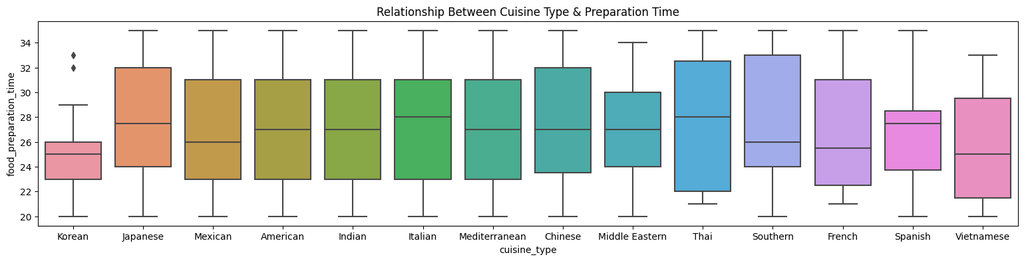

```python
plt.figure(figsize=(19,4))
plt.title("Relationship Between Cuisine Type & Preparation Time")
sns.boxplot(data, x='cuisine_type', y='food_preparation_time')
plt.show;
```

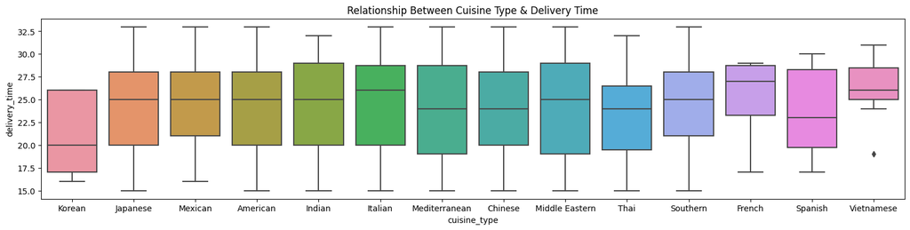

```python
plt.figure(figsize=(19,4))
plt.title("Relationship Between Cuisine Type & Delivery Time")
sns.boxplot(data, x='cuisine_type', y='delivery_time')
plt.show;
```

#### **Relationship Between Rating & Other Variables**

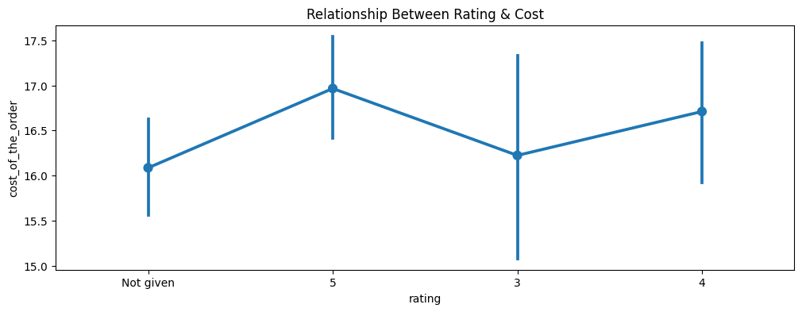

```python
plt.figure(figsize=(12,4))
plt.title("Relationship Between Rating & Cost")
sns.pointplot(data, x='rating', y='cost_of_the_order')
plt.show;
```

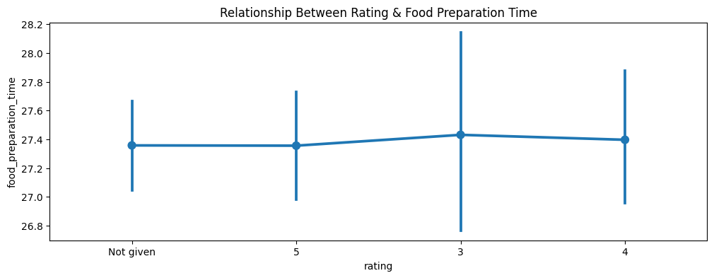

```python
plt.figure(figsize=(12,4))
plt.title("Relationship Between Rating & Food Preparation Time")
sns.pointplot(data, x='rating', y='food_preparation_time')
plt.show;
```

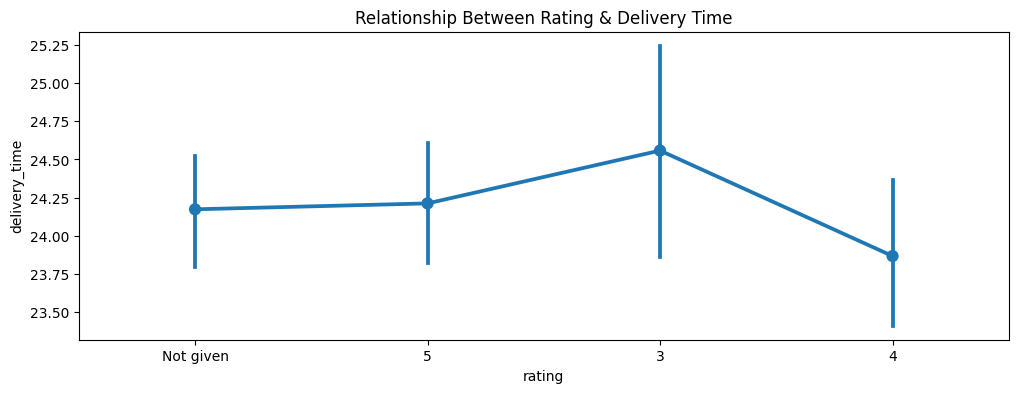

```python
plt.figure(figsize=(12,4))
plt.title("Relationship Between Rating & Delivery Time")
sns.pointplot(data, x='rating', y='delivery_time')
plt.show;
```

#### **Relationship Between Day of the Week & Other Variables**

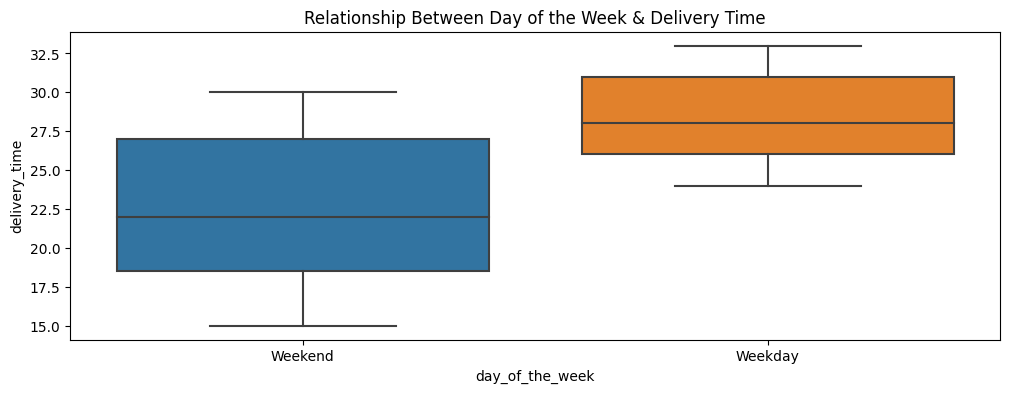

```python
plt.figure(figsize=(12,4))
plt.title("Relationship Between Day of the Week & Delivery Time")
sns.boxplot(data, x='day_of_the_week', y='delivery_time')
plt.show;
```

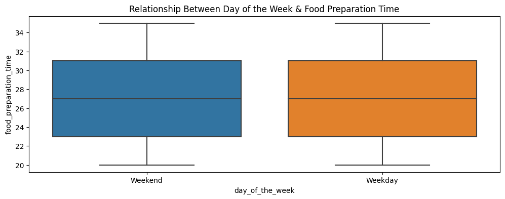

```python
plt.figure(figsize=(12,4))
plt.title("Relationship Between Day of the Week & Food Preparation Time")
sns.boxplot(data, x='day_of_the_week', y='food_preparation_time')
plt.show;
```

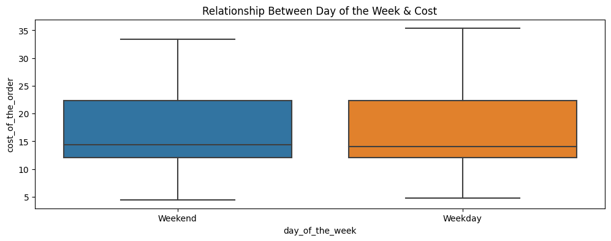

```python
plt.figure(figsize=(12,4))
plt.title("Relationship Between Day of the Week & Cost")
sns.boxplot(data, x='day_of_the_week', y='cost_of_the_order')
plt.show;
```

#### **Relationship Between Restaurant Name & Other Variables**

```python
data_rest_cost_max = data.groupby(['restaurant_name'])['cost_of_the_order'].sum().sort_values(ascending=False).head(15)
data_rest_cost_min = data.groupby(['restaurant_name'])['cost_of_the_order'].sum().sort_values(ascending=True).head(15)

print("\033[1mTop 15 restaurants with the highest sum of cost (in dollars):\033[0m\n", data_rest_cost_max, "\n")
print("\033[1mTop 15 restaurants with the lowest sum of cost (in dollars):\033[0m\n", data_rest_cost_min, "\n")
```

```
Top 15 restaurants with the highest sum of cost (in dollars):
 restaurant_name
Shake Shack                      3579.53
The Meatball Shop                2145.21
Blue Ribbon Sushi                1903.95
Blue Ribbon Fried Chicken        1662.29
Parm                             1112.76
RedFarm Broadway                  965.13
RedFarm Hudson                    921.21
TAO                               834.50
Han Dynasty                       755.29
Blue Ribbon Sushi Bar & Grill     666.62
Rubirosa                          660.45
Sushi of Gari 46                  640.87
Nobu Next Door                    623.67
Five Guys Burgers and Fries       506.47
Momoya                            492.13
Name: cost_of_the_order, dtype: float64

Top 15 restaurants with the lowest sum of cost (in dollars):
 restaurant_name
Hunan Manor                       5.72
Cipriani Le Specialita            5.92
Big Wong Restaurant _¤¾Ñ¼        5.92
Wa Jeal                           6.74
Market Table                      6.79
La Follia                         8.05
'wichcraft                        8.10
Woorijip                          8.25
Chola Eclectic Indian Cuisine     8.73
Gaia Italian Cafe                 8.78
Lamarca Pasta                     9.22
Balade                            9.22
Samurai Mama                     11.64
Frank Restaurant                 12.08
The MasalaWala                   12.13
Name: cost_of_the_order, dtype: float64
```

```python
data_rest_prep_max = data.groupby(['restaurant_name'])['food_preparation_time'].mean().sort_values(ascending=False).head(10)
data_rest_prep_min = data.groupby(['restaurant_name'])['food_preparation_time'].mean().sort_values(ascending=True).head(10)

print("\033[1mTop 10 restaurants with the highest mean values of food preparation time (in minutes):\033[0m\n", data_rest_prep_max, "\n")
print("\033[1mTop 10 restaurants with the lowest mean values of food preparation time (in minutes):\033[0m\n", data_rest_prep_min, "\n")
```

```
Top 10 restaurants with the highest mean values of food preparation time (in minutes):
 restaurant_name
Cipriani Le Specialita        35.0
Sushi Choshi                  35.0
Kambi Ramen House             35.0
Klong                         35.0
Taro Sushi                    35.0
Spice Thai                    34.0
Alidoro                       34.0
Big Wong Restaurant _¤¾Ñ¼    34.0
Il Bambino                    34.0
Hot Kitchen                   33.0
Name: food_preparation_time, dtype: float64

Top 10 restaurants with the lowest mean values of food preparation time (in minutes):
 restaurant_name
Haru Gramercy Park            20.0
67 Burger                     20.0
Frank Restaurant              20.0
DespaÌ±a                      20.5
Sarabeth's West               21.0
Lucky Strike                  21.0
Song Thai Restaurant & Bar    21.0
Hampton Chutney Co.           21.0
Samurai Mama                  21.0
Market Table                  21.0
Name: food_preparation_time, dtype: float64
```

```python
data_rest_deliv_max = data.groupby(['restaurant_name'])['delivery_time'].mean().sort_values(ascending=False).head(10)
data_rest_deliv_min = data.groupby(['restaurant_name'])['delivery_time'].mean().sort_values(ascending=True).head(10)

print("\033[1mTop 10 restaurants with the highest mean values of delivery time (in minutes):\033[0m\n", data_rest_deliv_max, "\n")
print("\033[1mTop 10 restaurants with the lowest mean values of delivery time (in minutes):\033[0m\n", data_rest_deliv_min, "\n")
```

```
Top 10 restaurants with the highest mean values of delivery time (in minutes):
 restaurant_name
Sarabeth's West          33.0
Taro Sushi               32.0
Haru Gramercy Park       32.0
Frank Restaurant         31.0
Haandi                   30.5
Chote Nawab              30.0
Rye House                30.0
Philippe Chow            30.0
Le Zie 2000 Trattoria    30.0
Carmine's                30.0
Name: delivery_time, dtype: float64

Top 10 restaurants with the lowest mean values of delivery time (in minutes):
 restaurant_name
Gaia Italian Cafe    15.0
Paul & Jimmy's       15.0
The MasalaWala       15.0
Hibino               15.0
Coppola's East       16.0
Galli Restaurant     16.0
Wo Hop Restaurant    16.0
Market Table         17.0
Byblos Restaurant    18.0
Samurai Mama         18.0
Name: delivery_time, dtype: float64
```

#### **Correlation Between Numerical Variables**

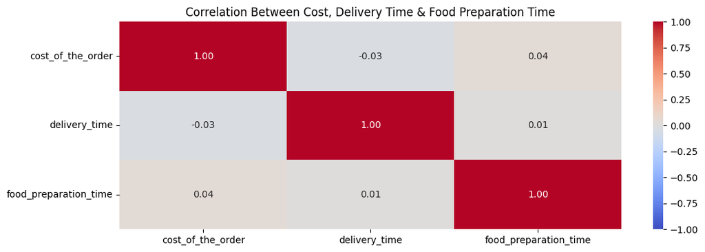

```python
corr_1 = ['cost_of_the_order', 'delivery_time', 'food_preparation_time']
plt.figure(figsize=(12,4))
plt.title("Correlation Between Cost, Delivery Time & Food Preparation Time")
sns.heatmap(data[corr_1].corr(), annot=True, vmin=-1, vmax=1, fmt=".2f", cmap="coolwarm")
plt.show;
```

### **Question 13**

```python
rated_rest = data[data['rating'] != 'Not given'].copy()
rated_rest['rating'] = rated_rest['rating'].astype('int')
```

```python
rated_rest_count = rated_rest.groupby(['restaurant_name'])['rating'].count().sort_values(ascending=False).reset_index()
rated_rest_count.head(10)
```

|  | restaurant_name | rating |
| --- | --- | --- |
| 0 | Shake Shack | 133 |
| 1 | The Meatball Shop | 84 |
| 2 | Blue Ribbon Sushi | 73 |
| 3 | Blue Ribbon Fried Chicken | 64 |
| 4 | RedFarm Broadway | 41 |
| 5 | Parm | 39 |
| 6 | RedFarm Hudson | 34 |
| 7 | TAO | 28 |
| 8 | Rubirosa | 24 |
| 9 | Nobu Next Door | 23 |

```python
rated_rest_name = rated_rest_count[rated_rest_count['rating']>50]['restaurant_name']
rated_rest_50 = rated_rest[rated_rest['restaurant_name'].isin(rated_rest_name)].copy()
```

```python
rated_rest_50.groupby(['restaurant_name'])['rating'].mean().sort_values(ascending=False).reset_index().dropna()
```

|  | restaurant_name | rating |
| --- | --- | --- |
| 0 | The Meatball Shop | 4.511905 |
| 1 | Blue Ribbon Fried Chicken | 4.328125 |
| 2 | Shake Shack | 4.278195 |
| 3 | Blue Ribbon Sushi | 4.219178 |

**Observation:** Only 4 restaurants can qualify for the promotional offer since they have a rating count of more than 50 and average rating of more than 4. These restaurant brands include The Meatball Shop, Blue Ribbon Fried Chicken, Shake Shack and Blue Ribbon Sushi.

### **Question 14**

```python
def func_rev(i):
  if i > 20:
    return i*0.25
  elif i > 5:
    return i*0.15
  else:
    return i*0
```

```python
data['Revenue'] = data['cost_of_the_order'].apply(func_rev)
data.head(10)
```

[output not shown]

```python
net_rev = data['Revenue'].sum()
net_rev_rounded = round(net_rev, 3)
print("\033[1mObservation:\033[0m The net revenue is $", net_rev_rounded, " after the company charges restaurants 25% on orders having cost greater than $20 and 15% on orders greater than $5.", sep='')
```

```
Observation: The net revenue is $6166.303 after the company charges restaurants 25% on orders having cost greater than $20 and 15% on orders greater than $5.
```

#### **Question 15**

```python
data['total_time'] = data['delivery_time'] + data['food_preparation_time']
```

```python
data[data['total_time']>60].shape[0]
```

```
200
```

```python
total_time_percent = (data[data['total_time']>60].shape[0])/(data.shape[0])*100
```

```python
print("\033[1mObservation:\033[0m The percentage of orders taking more than 60 minutes to get delivered from the time the order is placed is ", round(total_time_percent, 2), "%.", sep='')
```

```
Observation: The percentage of orders taking more than 60 minutes to get delivered from the time the order is placed is 10.54%.
```

#### **Question 16**

```python
delivery_time_weekend = data[data['day_of_the_week']=='Weekday']['delivery_time'].mean()
delivery_time_weekday = data[data['day_of_the_week']=='Weekend']['delivery_time'].mean()

print(delivery_time_weekend)
print(delivery_time_weekday)

delivery_time_diff = delivery_time_weekend - delivery_time_weekday
print(delivery_time_diff)
```

```
28.340036563071298
22.4700222057735
5.870014357297798
```

## **Project 1: Food Hub Data Analysis Assignment**

### **Setting Up**

```python
import numpy as np
import pandas as pd

import matplotlib.pyplot as plt
import seaborn as sns
```

```python
from google.colab import drive
drive.mount('/content/drive')
```

```python
data = pd.read_csv('/content/drive/MyDrive/Data Science & Business Analytics Program/Python Foundations/Project/foodhub_order.csv')
```

### **Question 1**

```python
data.shape
```

```
(1898, 9)
```

```python
print("\033[1mObservation:\033[0m There are", data.shape[0], 'rows and', data.shape[1], "columns present in this dataset.")
```

```
Observation: There are 1898 rows and 9 columns present in this dataset.
```

### **Question 2**

```python
data.info()
```

```
<class 'pandas.core.frame.DataFrame'>
RangeIndex: 1898 entries, 0 to 1897
Data columns (total 9 columns):
 #   Column                 Non-Null Count  Dtype
---  ------                 --------------  -----
 0   order_id               1898 non-null   int64
 1   customer_id            1898 non-null   int64
 2   restaurant_name        1898 non-null   object
 3   cuisine_type           1898 non-null   object
 4   cost_of_the_order      1898 non-null   float64
 5   day_of_the_week        1898 non-null   object
 6   rating                 1898 non-null   object
 7   food_preparation_time  1898 non-null   int64
 8   delivery_time          1898 non-null   int64
dtypes: float64(1), int64(4), object(4)
memory usage: 133.6+ KB
```

**Observation:** The datatypes of the different columns in the dataset include *int*, *float*, and *object*.

### **Question 3**

```python
data['order_id'].unique()
```

```
array([1477147, 1477685, 1477070, ..., 1477819, 1477513, 1478056])
```

```python
data['customer_id'].unique()
```

```
array([337525, 358141,  66393, ...,  97838, 292602, 397537])
```

```python
data['restaurant_name'].unique()
```

```
array(['Hangawi', 'Blue Ribbon Sushi Izakaya', 'Cafe Habana',
       'Blue Ribbon Fried Chicken', 'Dirty Bird to Go',
       'Tamarind TriBeCa', 'The Meatball Shop', 'Barbounia',
       'Anjappar Chettinad', 'Bukhara Grill',
       'Big Wong Restaurant \x8c_¤¾Ñ¼', 'Empanada Mama (closed)', 'Pylos',
       "Lucky's Famous Burgers", 'Shake Shack', 'Sushi of Gari',
       'RedFarm Hudson', 'Blue Ribbon Sushi',
       'Five Guys Burgers and Fries', 'Tortaria', 'Cafe Mogador',
       'Otto Enoteca Pizzeria', 'Vezzo Thin Crust Pizza',
       'Sushi of Gari 46', 'The Kati Roll Company', 'Klong',
       '5 Napkin Burger', 'TAO', 'Parm', 'Sushi Samba',
       'Haru Gramercy Park', 'Chipotle Mexican Grill $1.99 Delivery',
       'RedFarm Broadway', 'Cafeteria', 'DuMont Burger',
       "Sarabeth's East", 'Hill Country Fried Chicken', 'Bistango',
       "Jack's Wife Freda", "Mamoun's Falafel", 'Prosperity Dumpling',
       'Blue Ribbon Sushi Bar & Grill', 'Westville Hudson',
       'Blue Ribbon Brooklyn', 'Nobu Next Door', 'Osteria Morini',
       'Haandi', 'Benihana', 'Han Dynasty', 'Chote Nawab',
       'Mission Cantina', "Xi'an Famous Foods", 'Rubirosa',
       "Joe's Shanghai \x8e_À\x8eü£¾÷´", 'Bareburger', 'The Odeon',
       'Pongsri Thai', 'Yama Japanese Restaurant', 'Momoya',
       'Balthazar Boulangerie', 'CafÌ© China', 'Boqueria',
       'Song Thai Restaurant & Bar', 'Five Leaves',
       'Pinto Nouveau Thai Bistro', "Amy Ruth's", 'Pepe Giallo',
       'indikitch', 'Yama 49', 'Piccolo Angolo', 'Pepe Rosso To Go',
       "L'Express", 'Amma', 'Delicatessen', "S'MAC",
       "Vanessa's Dumplings", 'Bhatti Indian Grill', 'Taro Sushi',
       'Donburi-ya', 'Hatsuhana', 'Samurai Mama', 'Waverly Diner',
       'Tarallucci e Vino Restaurant', "P.J. Clarke's",
       'Lantern Thai Kitchen', 'ilili Restaurant', 'The Smile',
       "Vanessa's Dumpling House", "Bubby's ", 'Woorijip',
       'Dirty Bird To Go (archived)', 'Haveli Indian Restaurant',
       'Dos Caminos', 'da Umberto', 'Sushi of Gari Tribeca',
       'Burger Joint', 'Room Service', "Sarabeth's Restaurant",
       'Xe May Sandwich Shop', 'Hibino', 'Mira Sushi', 'Melt Shop',
       'J. G. Melon', 'Hummus Place', 'Saravanaa Bhavan',
       'Friend of a Farmer', 'The Loop', 'Balade', 'Posto',
       'Terakawa Ramen', 'Kambi Ramen House', 'Wo Hop Restaurant',
       'Spice Thai', "Dickson's Farmstand Meats",
       'UVA Wine Bar & Restaurant', 'Serafina Fabulous Pizza',
       'Gaia Italian Cafe', 'Chola Eclectic Indian Cuisine',
       'Hot Kitchen', 'Junoon', 'Ravagh Persian Grill', 'Rohm Thai',
       'Dig Inn Seasonal Market', 'Olea', 'Cho Dang Gol',
       'El Parador Cafe', 'Socarrat Paella Bar',
       "Don's Bogam BBQ & Wine Bar", 'Alidoro', "Tony's Di Napoli",
       'Cipriani Le Specialita', 'Sushi Choshi', 'Kanoyama', 'V-Nam Cafe',
       'Zero Otto Nove', 'Dos Caminos Soho', 'Go! Go! Curry!',
       'La Follia', 'Izakaya Ten', '12 Chairs', 'Philippe Chow',
       'The MasalaWala', 'brgr', "Carmine's", 'Asuka Sushi', 'Aurora',
       "Sarabeth's", 'Crema Restaurante', "Big Daddy's",
       'Moonstruck on Second', 'Cafe de La Esquina', 'Olive Garden',
       '67 Burger', 'Tres Carnes', "Schnipper's Quality Kitchen",
       'Nha Trang One', 'Market Table', 'Galli Restaurant',
       'Hampton Chutney Co.', 'Byblos Restaurant',
       'Grand Sichuan International', 'Le Grainne Cafe', 'Il Bambino',
       'Kori Restaurant and Bar', 'DespaÌ±a', 'Lamarca Pasta',
       'Lucky Strike', "Paul & Jimmy's", 'Hunan Manor', "Coppola's East",
       'Emporio', 'Wa Jeal', 'Le Zie 2000 Trattoria', 'Rye House',
       "Hiroko's Place", 'Frank Restaurant', "Sarabeth's West",
       "'wichcraft"], dtype=object)
```

```python
data['cuisine_type'].unique()
```

```
array(['Korean', 'Japanese', 'Mexican', 'American', 'Indian', 'Italian',
       'Mediterranean', 'Chinese', 'Middle Eastern', 'Thai', 'Southern',
       'French', 'Spanish', 'Vietnamese'], dtype=object)
```

```python
data['cost_of_the_order'].unique()
```

```
array([30.75, 12.08, 12.23, 29.2 , 11.59, 25.22,  6.07,  5.97, 16.44,
        7.18,  5.92,  8.1 , 24.3 , 11.3 , 12.13, 16.2 , 16.98, 33.03,
       14.12, 24.2 , 15.91, 29.1 ,  8.92, 15.86, 21.88, 14.02,  9.17,
       12.18, 31.33, 29.05,  8.39,  9.12, 15.47, 16.01, 29.83, 19.89,
       19.35, 33.22, 24.25, 22.75,  6.74, 13.78, 16.93, 29.39, 20.23,
       14.6 ,  6.79, 31.38,  8.34, 12.46, 14.55, 32.93,  8.  , 13.05,
        5.67, 29.29, 16.15, 13.34,  9.75,  6.69,  4.75, 12.56, 21.2 ,
       19.31, 16.3 , 25.27, 14.79,  5.72,  9.22, 16.39, 17.03, 21.83,
       31.29, 11.83, 22.26, 20.47, 15.81, 22.36,  8.68, 12.9 , 29.15,
        7.86, 16.1 , 12.95, 11.69, 12.32, 14.99, 10.38,  9.65,  5.77,
        9.56, 29.34, 11.16, 14.07, 22.8 , 15.23, 16.49,  8.83, 16.25,
       16.83, 10.24, 19.4 , 13.97, 13.  ,  8.49, 20.18, 19.59, 16.11,
       12.27, 13.39,  9.02, 15.33, 31.43, 29.35, 15.28,  9.6 ,  8.88,
       15.96,  8.05,  8.54,  7.23, 19.69,  9.27,  8.97, 11.64, 13.15,
        9.41,  9.07, 14.46,  6.7 , 19.45, 12.22, 29.25, 16.05, 17.08,
       32.98, 13.73, 14.31, 14.7 , 15.52,  6.11, 21.93, 15.76,  9.46,
       12.61, 22.85, 16.06, 21.39,  8.25, 14.94, 14.26, 21.34, 14.16,
        5.68, 15.57, 14.45,  8.15,  8.78,  8.59, 15.62,  5.87,  6.01,
        9.85,  6.84,  5.82,  7.96,  9.7 ,  4.85,  6.06, 12.66,  6.02,
        7.08, 12.37, 14.84, 22.31, 13.1 , 14.75, 24.35, 25.17,  9.26,
        9.55, 13.92,  4.66, 13.87,  7.61, 15.72,  8.35, 14.21, 14.65,
        4.71,  8.63, 13.68, 11.93, 35.41,  6.64, 10.72,  8.73, 16.78,
        5.58, 13.63, 29.54, 29.49, 15.04, 18.24,  4.47,  8.98, 15.71,
        8.93,  9.51,  9.61,  7.38, 13.19, 10.82,  6.26,  8.2 ,  7.33,
       12.71,  5.63, 17.07,  5.48, 22.12, 15.77,  6.45, 11.79, 11.98,
       20.32, 28.57, 22.07, 21.29, 14.41, 29.88,  4.8 , 10.14,  8.44,
       16.54,  7.71, 29.78, 31.86, 19.98, 12.42, 12.52, 15.38,  8.3 ,
       13.24,  8.01, 29.68,  9.32, 12.51,  5.34,  6.4 , 19.3 , 17.85,
       16.88, 13.77,  5.73, 11.84, 15.67, 13.58, 33.18,  6.55, 20.52,
       28.62, 15.18, 29.3 , 12.81, 29.44, 11.11, 14.5 , 22.02, 11.88,
       33.32, 18.43, 12.47, 20.13, 20.57, 15.09, 19.74, 18.04, 31.67,
        5.05,  7.03, 14.8 , 12.17,  7.28, 15.13,  7.81, 16.74,  9.31,
       21.25, 31.87, 19.02, 34.19,  5.53, 22.46, 29.73, 10.43, 19.5 ,
        4.9 , 15.37,  7.67,  7.91, 13.53, 33.37, 19.6 , 13.48, 20.71,
       20.61,  7.66, 10.86,  7.95, 20.86, 29.59])
```

```python
data['day_of_the_week'].unique()
```

```
array(['Weekend', 'Weekday'], dtype=object)
```

```python
data['rating'].unique()
```

```
array(['Not given', '5', '3', '4'], dtype=object)
```

```python
data['food_preparation_time'].unique()
```

```
array([25, 23, 20, 28, 33, 21, 29, 34, 24, 30, 35, 32, 31, 27, 22, 26])
```

```python
data['delivery_time'].unique()
```

```
array([20, 23, 28, 15, 24, 21, 30, 26, 22, 17, 25, 16, 29, 27, 18, 31, 32,
       19, 33])
```

```python
data[data['rating']=='Not given'].shape[0]
```

```
736
```

**Observation:** There is not any missing value in the data, as shown from the data summaries above. Additionally, the table given by the command 'data.info()' shows that every single column does not have any missing value as the number of non-null is 1898, which is exactly the number of rows there are in the dataset. However, one variable, 'rating', has 736 counts of 'not given' although this does not necessarily qualify as missing values.

### **Question 4**

```python
data['food_preparation_time'].describe()
```

```
count    1898.000000
mean       27.371970
std         4.632481
min        20.000000
25%        23.000000
50%        27.000000
75%        31.000000
max        35.000000
Name: food_preparation_time, dtype: float64
```

**Observation:** In terms of food preparation time once an order is placed, the minimum time is 20 minutes; the average time is around 27.37 minutes; and the maximum time is 35 minutes.

### **Question 5**

```python
data[data['rating']=='Not given'].shape[0]
```

```
736
```

```python
data[data['rating']=='Not given'].value_counts
```

```
<bound method DataFrame.value_counts of       order_id  customer_id             restaurant_name cuisine_type  \
0      1477147       337525                     Hangawi       Korean
1      1477685       358141   Blue Ribbon Sushi Izakaya     Japanese
6      1477894       157711           The Meatball Shop      Italian
10     1477895       143926  Big Wong Restaurant _¤¾Ñ¼      Chinese
14     1478198        62667      Lucky's Famous Burgers     American
...        ...          ...                         ...          ...
1887   1476873       237616                 Shake Shack     American
1891   1476981       138586                 Shake Shack     American
1892   1477473        97838                 Han Dynasty      Chinese
1895   1477819        35309           Blue Ribbon Sushi     Japanese
1897   1478056       120353           Blue Ribbon Sushi     Japanese

      cost_of_the_order day_of_the_week     rating  food_preparation_time  \
0                 30.75         Weekend  Not given                     25
```

[output cut: 25 more lines]

**Observation:** Based on the statistics above, there are 736 out of the total 1898 orders that are not rated.

### **Question 6**

#### **Statistics on Order ID**

```python
data['order_id'].nunique()
```

```
1898
```

**Observation:** There are a total of 1898 unique order IDs.

#### **Statistics on Customer ID**

```python
data['customer_id'].nunique()
```

```
1200
```

**Observation:** There are 1200 unique customer IDs, meaning that there are occurrences of different orders being made by the same customer.

#### **Statistics on Restaurant Name**

```python
data['restaurant_name'].nunique()
```

```
178
```

```python
pd.set_option("display.max_rows", None)
data['restaurant_name'].value_counts()
```

```
Shake Shack                              219
The Meatball Shop                        132
Blue Ribbon Sushi                        119
Blue Ribbon Fried Chicken                 96
Parm                                      68
RedFarm Broadway                          59
RedFarm Hudson                            55
TAO                                       49
Han Dynasty                               46
Blue Ribbon Sushi Bar & Grill             44
Nobu Next Door                            42
Rubirosa                                  37
Sushi of Gari 46                          37
Momoya                                    30
Five Guys Burgers and Fries               29
Blue Ribbon Sushi Izakaya                 29
Bareburger                                27
Tamarind TriBeCa                          27
Jack's Wife Freda                         25
Sushi of Gari Tribeca                     24
Chipotle Mexican Grill $1.99 Delivery     23
The Smile                                 18
ilili Restaurant                          18
Cafe Mogador                              18
Yama Japanese Restaurant                  18
The Kati Roll Company                     16
Sushi of Gari                             16
Cafe Habana                               16
P.J. Clarke's                             15
J. G. Melon                               15
Westville Hudson                          15
Osteria Morini                            14
Hill Country Fried Chicken                14
Empanada Mama (closed)                    13
Vanessa's Dumplings                       13
Burger Joint                              12
S'MAC                                     12
Otto Enoteca Pizzeria                     12
Melt Shop                                 11
Sushi Samba                               11
```

[output cut: 124 more lines]

```
Wo Hop Restaurant                          1
Spice Thai                                 1
Gaia Italian Cafe                          1
Chola Eclectic Indian Cuisine              1
Rohm Thai                                  1
Dig Inn Seasonal Market                    1
Socarrat Paella Bar                        1
Alidoro                                    1
Cipriani Le Specialita                     1
Sushi Choshi                               1
Dos Caminos Soho                           1
La Follia                                  1
Philippe Chow                              1
'wichcraft                                 1
Name: restaurant_name, dtype: int64
```

#### **Statistics on Cuisine Type**

```python
data['cuisine_type'].nunique()
```

```
14
```

```python
pd.set_option("display.max_rows", None)
data['cuisine_type'].value_counts()
```

```
American          584
Japanese          470
Italian           298
Chinese           215
Mexican            77
Indian             73
Middle Eastern     49
Mediterranean      46
Thai               19
French             18
Southern           17
Korean             13
Spanish            12
Vietnamese          7
Name: cuisine_type, dtype: int64
```

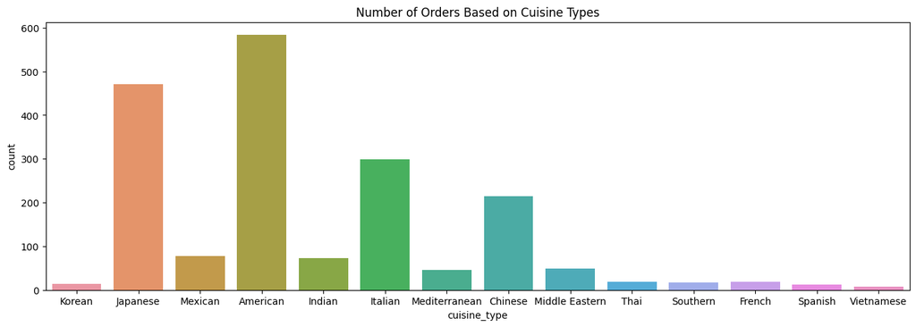

```python
plt.figure(figsize=(16,5))
plt.title("Number of Orders Based on Cuisine Types")
sns.countplot(data,x='cuisine_type')
plt.show;
```

**Observation:** There are 14 different types of cuisines listed in the dataset. Most of which are American, followed by Japanese, Italian and Chinese, with 584, 470, 298 and 215 orders respectively. The least popular cuisine type is Vietnamese with only 7 orders.

#### **Statistics on Cost of the Order**

```python
data['cost_of_the_order'].describe()
```

```
count    1898.000000
mean       16.498851
std         7.483812
min         4.470000
25%        12.080000
50%        14.140000
75%        22.297500
max        35.410000
Name: cost_of_the_order, dtype: float64
```

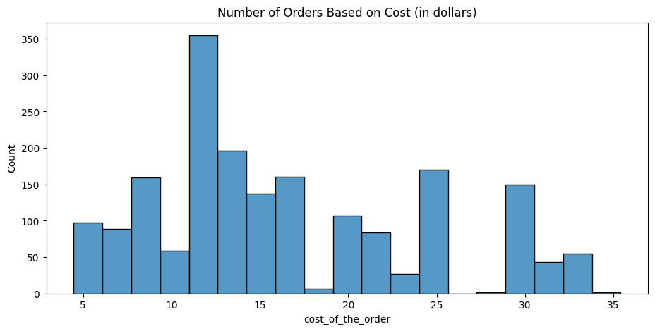

```python
plt.figure(figsize=(11,5))
plt.title("Number of Orders Based on Cost (in dollars)")
sns.histplot(data,x='cost_of_the_order')
plt.show;
```

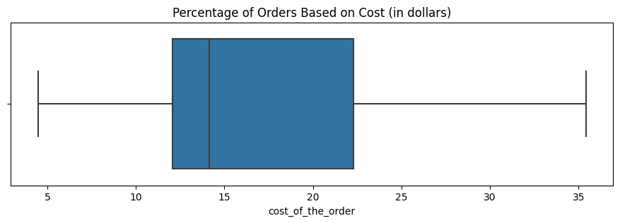

```python
plt.figure(figsize=(11,3))
plt.title("Percentage of Orders Based on Cost (in dollars)")
sns.boxplot(data,x='cost_of_the_order')
plt.show;
```

**Observation:** Based on the statistics and graphs above, one can see that the average cost is around 16.50 dollars; the lowest cost is 4.47 dollars and the highest cost is 35.41 dollars. The median cost is 14.14 dollars. Additionally, 25% of orders (1st quartile) have the cost of 12.08 dollars or less and 75% of orders (3rd quartile) have the cost of around 22.30 dollars or less.

#### **Statistics on Day of the Week**

```python
data['day_of_the_week'].nunique()
```

```
2
```

```python
data['day_of_the_week'].value_counts()
```

```
Weekend    1351
Weekday     547
Name: day_of_the_week, dtype: int64
```

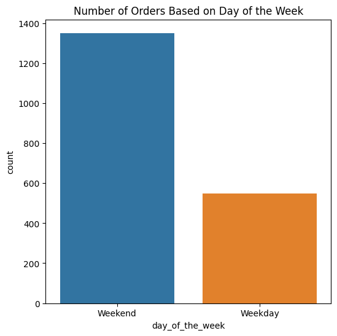

```python
plt.figure(figsize=(6,6))
plt.title("Number of Orders Based on Day of the Week")
sns.countplot(data,x='day_of_the_week')
plt.show;
```

**Observation:** The dataset only has weekends and weekdays, rather than the individual days themselves. There are 1351 orders on the weekend, whereas there are only 547 orders on the weekdays. This shows that despite the weekends having only two days, most people would rather order food, while on the weekdays, it can be assumed that people tend to cook food for themselves.

#### **Statistics on Rating**

```python
data['rating'].unique()
```

```
array(['Not given', '5', '3', '4'], dtype=object)
```

```python
data['rating'].nunique()
```

```
4
```

```python
pd.set_option("display.max_rows", None)
data['rating'].value_counts()
```

```
Not given    736
5            588
4            386
3            188
Name: rating, dtype: int64
```

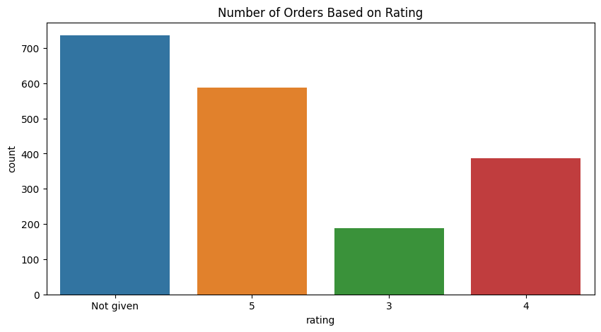

```python
plt.figure(figsize=(10,5))
plt.title("Number of Orders Based on Rating")
sns.countplot(data,x='rating')
plt.show;
```

**Observation:** In terms of rating, there are only 4 different types: 'not given', '5', '4' and '3'; there is no '2' or '1'. The rating that has the most orders is 'not given', with 736 orders, while the rating with the least amount of orders is '3', with only 188 orders.

#### **Statistics on Food Preparation Time**

```python
data['food_preparation_time'].describe()
```

```
count    1898.000000
mean       27.371970
std         4.632481
min        20.000000
25%        23.000000
50%        27.000000
75%        31.000000
max        35.000000
Name: food_preparation_time, dtype: float64
```

```python
pd.set_option("display.max_rows", None)
data['food_preparation_time'].value_counts()
```

```
21    135
23    123
27    123
22    123
28    121
24    121
20    119
30    119
33    118
35    117
31    116
26    115
25    113
34    113
32    113
29    109
Name: food_preparation_time, dtype: int64
```

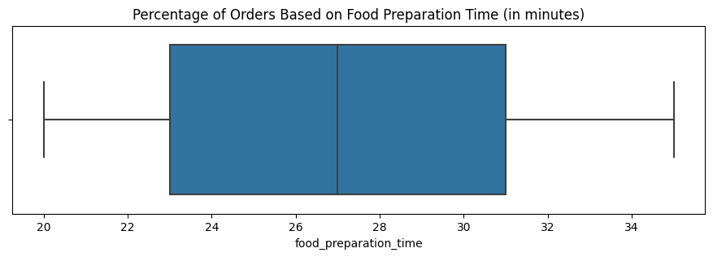

```python
plt.figure(figsize=(11,3))
plt.title("Percentage of Orders Based on Food Preparation Time (in minutes)")
sns.boxplot(data,x='food_preparation_time')
plt.show;
```

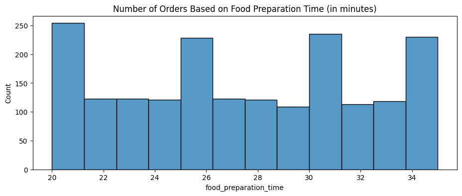

```python
plt.figure(figsize=(11,4))
plt.title("Number of Orders Based on Food Preparation Time (in minutes)")
sns.histplot(data,x='food_preparation_time')
plt.show;
```

**Observation:** As mentioned earlier, the mean food preparation time is 27.37 minutes, while the minimum and maximum are 20 and 35 minutes respectively. Most of the orders are done within 21 minutes with 135 orders, and the food preparation time with the least amount of orders is 29 minutes with 109 orders. About 25% of all food orders are prepared within 23 minutes and 75% of orders are prepared within 31 minutes.

#### **Statistics on Delivery Time**

```python
data['delivery_time'].describe()
```

```
count    1898.000000
mean       24.161749
std         4.972637
min        15.000000
25%        20.000000
50%        25.000000
75%        28.000000
max        33.000000
Name: delivery_time, dtype: float64
```

```python
pd.set_option("display.max_rows", None)
data['delivery_time'].value_counts()
```

```
24    162
28    148
29    148
26    141
27    138
30    133
25    120
19     90
16     90
20     88
15     87
22     85
18     83
21     81
17     78
23     77
32     59
33     49
31     41
Name: delivery_time, dtype: int64
```

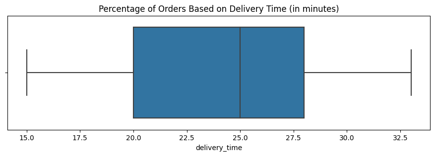

```python
plt.figure(figsize=(11,3))
plt.title("Percentage of Orders Based on Delivery Time (in minutes)")
sns.boxplot(data,x='delivery_time')
plt.show;
```

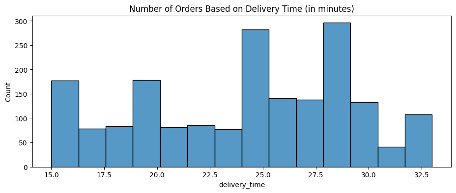

```python
plt.figure(figsize=(11,4))
plt.title("Number of Orders Based on Delivery Time (in minutes)")
sns.histplot(data,x='delivery_time')
plt.show;
```

### **Question 7**

```python
data['restaurant_name'].value_counts().nlargest(n=5)
```

```
Shake Shack                  219
The Meatball Shop            132
Blue Ribbon Sushi            119
Blue Ribbon Fried Chicken     96
Parm                          68
Name: restaurant_name, dtype: int64
```

**Observation:** The top 5 restaurants with the most number of orders received (from most to least) are Shake Shack, The Meatball Shop, Blue Ribbon Sushi, Blue Ribbon Fried Chicken and Parm.

### **Question 8**

```python
data_weekend_cuisine = data[data['day_of_the_week']=='Weekend']
data_weekend_cuisine['cuisine_type'].value_counts().nlargest(n=1)
```

```
American    415
Name: cuisine_type, dtype: int64
```

**Observation:** On the weekends, the most popular cuisine is American with 415 of the total 1898 orders.

### **Question 9**

```python
data[data['cost_of_the_order']>20].shape[0]
```

```
555
```

```python
(data[data['cost_of_the_order']>20].shape[0])/(data.shape[0])*100
```

```
29.24130663856691
```

```python
data_percent_20_dollars = data[data['cost_of_the_order']>20].shape[0]/(data.shape[0])*100

data_percent_20_dollars_rounded = str(round(data_percent_20_dollars, 2))
```

```python
print("\033[1mObservation:\033[0m There are ", data[data['cost_of_the_order']>20].shape[0], " orders that cost more than 20 dollars, which is approximately ", data_percent_20_dollars_rounded, "% of the total orders.", sep='')
```

```
Observation: There are 555 orders that cost more than 20 dollars, which is approximately 29.24% of the total orders.
```

### **Question 10**

```python
data_deliv_mean = data['delivery_time'].mean()
```

```python
data_deliv_mean_rounded = str(round(data_deliv_mean, 2))
```

```python
print("\033[1mObservation:\033[0m The mean order delivery time is", data_deliv_mean_rounded, "minutes.")
```

```
Observation: The mean order delivery time is 24.16 minutes.
```

### **Question 11**

```python
data['customer_id'].value_counts().nlargest(n=3)
```

```
52832    13
47440    10
83287     9
Name: customer_id, dtype: int64
```

**Observation:** The top 3 most frequent customers that can benefit from the 20% discount have the following IDs: '52832', '47440' and '83287'.